# Python数据处理

## 15. PyTorch和Tensorboard

主讲人：丁平尖

## Numpy

- 使用 numpy 来拟合三阶多项式到正弦函数
- 使用 numpy 手动实现通过网络的前向和后向传递

```python
import numpy as np
import math
# Create random input and output data
x = np.linspace(-math.pi, math.pi, 2000); y = np.sin(x)
# Randomly initialize weights
a, b, c, d = np.random.randn(), np.random.randn(), np.random.randn(), np.random.randn()
learning_rate = 1e-6
for t in range(2000):
    # Forward pass: compute predicted y
    # y = a + b x + c x^2 + d x^3
    y_pred = a + b * x + c * x ** 2 + d * x ** 3
    # Compute and print loss
    loss = np.square(y_pred - y).sum()
    if t % 100 == 99:
        print(t, loss)
    # Backprop to compute gradients of a, b, c, d with respect to loss
    grad_y_pred = 2.0 * (y_pred - y)
    grad_a = grad_y_pred.sum()
    grad_b = (grad_y_pred * x).sum()
    grad_c = (grad_y_pred * x ** 2).sum()
    grad_d = (grad_y_pred * x ** 3).sum()
    # Update weights
    a -= learning_rate * grad_a
    b -= learning_rate * grad_b
    c -= learning_rate * grad_c
    d -= learning_rate * grad_d
print(f'Result: y = {a} + {b} x + {c} x^2 + {d} x^3')
```

```
99 886.6224037631865
199 629.2292060666061
299 447.34710555467234
399 318.80931904283386
499 227.9626428891946
599 163.74974434293713
699 118.35889657765176
799 86.2707214623376
899 63.58510974912219
999 47.54590296582326
1099 36.20518694900068
1199 28.18616045469913
1299 22.515614250538913
1399 18.50557342953937
1499 15.669666192577145
1599 13.664024582838099
1699 12.245517336651243
1799 11.242229350041601
1899 10.532595262323262
1999 10.030649060639465
Result: y = -0.03677535675138621 + 0.8542833949812978 x + 0.0063443609841918784 x^2 + -0.09298083844908889 x^3
```

## PyTorch: 张量

- Numpy 无法利用 GPU 来加速其数值计算。
- 使用 PyTorch 张量将三阶多项式拟合为正弦函数
- 手动实现通过网络的前向和后向传递

```python
import torch
dtype = torch.float
device = torch.device("cpu")
# device = torch.device("cuda:0") # Uncomment this to run on GPU
# Create random input and output data
x = torch.linspace(-math.pi, math.pi, 2000, device=device, dtype=dtype)
y = torch.sin(x)
# Randomly initialize weights
a, b, c, d = torch.randn((), device=device, dtype=dtype), torch.randn((), device=device, dtype=dtype), torch.randn((), device=device, dtype=dtype), torch.randn((), device=device, dtype=dtype)
learning_rate = 1e-6
for t in range(2000):
    # Forward pass: compute predicted y
    y_pred = a + b * x + c * x ** 2 + d * x ** 3
    # Compute and print loss
    loss = (y_pred - y).pow(2).sum().item()
    if t % 100 == 99:
        print(t, loss)
    # Backprop to compute gradients of a, b, c, d with respect to loss
    grad_y_pred = 2.0 * (y_pred - y)
    grad_a = grad_y_pred.sum()
    grad_b = (grad_y_pred * x).sum()
    grad_c = (grad_y_pred * x ** 2).sum()
    grad_d = (grad_y_pred * x ** 3).sum()
    # Update weights using gradient descent
    a -= learning_rate * grad_a
    b -= learning_rate * grad_b
    c -= learning_rate * grad_c
    d -= learning_rate * grad_d
print(f'Result: y = {a.item()} + {b.item()} x + {c.item()} x^2 + {d.item()} x^3')
```

```
99 677.9607543945312
199 473.0617370605469
299 331.2071533203125
399 232.90127563476562
499 164.70883178710938
599 117.36085510253906
699 84.45564270019531
799 61.56745910644531
899 45.633277893066406
999 34.53114700317383
1099 26.789535522460938
1199 21.387123107910156
1299 17.614286422729492
1399 14.977657318115234
1499 13.133779525756836
1599 11.84348201751709
1699 10.940007209777832
1799 10.307008743286133
1899 9.863264083862305
1999 9.552023887634277
Result: y = -0.027143917977809906 + 0.8481974601745605 x + 0.00468277744948864 x^2 + -0.09211516380310059 x^3
```

## 自动梯度

- 在上面的例子中，我们必须手动实现神经网络的前向和后向传递
  - 对于大型复杂网络来说，这很快就会变得非常棘手
- 使用自动微分 来自动计算神经网络中的反向传递
- 张量x的属性x.requires_grad=True，则表示反向传播时需要计算梯度，x.grad将存储其梯度值
- 使用 PyTorch Tensors 和 autograd 来实现带有三阶多项式示例的拟合正弦函数；
  - 现在我们不再需要手动实现通过网络的反向传递

```python
dtype = torch.float
device = "cuda" if torch.cuda.is_available() else "cpu"
torch.set_default_device(device)
x = torch.linspace(-math.pi, math.pi, 2000, dtype=dtype)
y = torch.sin(x)
a, b, c, d = torch.randn((), dtype=dtype, requires_grad=True), torch.randn((), dtype=dtype, requires_grad=True), torch.randn((), dtype=dtype, requires_grad=True), torch.randn((), dtype=dtype, requires_grad=True)
learning_rate = 1e-6
for t in range(2000):
    # Forward pass: compute predicted y using operations on Tensors.
    y_pred = a + b * x + c * x ** 2 + d * x ** 3
    # loss.item() gets the scalar value held in the loss.
    loss = (y_pred - y).pow(2).sum()
    if t % 100 == 99:
        print(t, loss.item())
    # the gradient of the loss with respect to a, b, c, d respectively.
    loss.backward()
    # Manually update weights using gradient descent. Wrap in torch.no_grad()
    # because weights have requires_grad=True, but we don't need to track this
    # in autograd.
    with torch.no_grad():
        a -= learning_rate * a.grad
        b -= learning_rate * b.grad
        c -= learning_rate * c.grad
        d -= learning_rate * d.grad
        # Manually zero the gradients after updating weights
        a.grad, b.grad, c.grad, d.grad = None, None, None, None
print(f'Result: y = {a.item()} + {b.item()} x + {c.item()} x^2 + {d.item()} x^3')
```

```
99 195.7766876220703
199 136.6044464111328
299 96.26067352294922
399 68.72262573242188
499 49.90393829345703
599 37.02909851074219
699 28.210630416870117
799 22.163551330566406
899 18.012170791625977
999 15.159011840820312
1099 13.195876121520996
1199 11.843607902526855
1299 10.91112995147705
1399 10.267412185668945
1499 9.822571754455566
1599 9.514861106872559
1699 9.301766395568848
1799 9.154065132141113
1899 9.051584243774414
1999 8.980417251586914
Result: y = -0.011865215376019478 + 0.8507804870605469 x + 0.002046945970505476 x^2 + -0.09248258173465729 x^3
```

## PyTorch：nn.Module

- nn 包定义了一组module，它们大致相当于神经网络层
  - 模块接收输入张量并计算输出张量
- nn包还定义了一组有用的损失函数

```python
x = torch.linspace(-math.pi, math.pi, 2000)
y = torch.sin(x)
# For this example, the output y is a linear function of (x, x^2, x^3), so
# we can consider it as a linear layer neural network. Let's prepare the
# tensor (x, x^2, x^3).
p = torch.tensor([1, 2, 3])
xx = x.unsqueeze(-1).pow(p)
# In the above code, x.unsqueeze(-1) has shape (2000, 1), and p has shape
# (3,), for this case, broadcasting semantics will apply to obtain a tensor
# of shape (2000, 3)

model = torch.nn.Sequential(
    torch.nn.Linear(3, 1),
    torch.nn.Flatten(0, 1)
)

# The nn package also contains definitions of popular loss functions; in this
# case we will use Mean Squared Error (MSE) as our loss function.
loss_fn = torch.nn.MSELoss(reduction='sum')

learning_rate = 1e-6
```

```python
for t in range(2000):
    y_pred = model(xx)

    loss = loss_fn(y_pred, y)
    if t % 100 == 99:
        print(t, loss.item())

    # Zero the gradients before running the backward pass.
    model.zero_grad()

    # all learnable parameters in the model.
    loss.backward()

    # Update the weights using gradient descent. Each parameter is a Tensor, so
    # we can access its gradients like we did before.
    with torch.no_grad():
        for param in model.parameters():
            param -= learning_rate * param.grad

# You can access the first layer of `model` like accessing the first item of a list
linear_layer = model[0]

# For linear layer, its parameters are stored as `weight` and `bias`.
print(f'Result: y = {linear_layer.bias.item()} + {linear_layer.weight[:, 0].item()} x + {linear_layer.weight[:, 1].item()} x^2 + {linear_layer.weight[:, 2].item()} x^3')
```

```
99 420.62548828125
199 285.8297119140625
299 195.3209686279297
399 134.4989013671875
499 93.59147644042969
599 66.0538558959961
699 47.499908447265625
799 34.98699188232422
899 26.540008544921875
999 20.83228302001953
1099 16.971538543701172
1199 14.357422828674316
1299 12.585514068603516
1399 11.383183479309082
1499 10.566455841064453
1599 10.011048316955566
1699 9.632920265197754
1799 9.375188827514648
1899 9.199324607849121
1999 9.079187393188477
Result: y = 0.012617216445505619 + 0.8460951447486877 x + -0.0021766796708106995 x^2 + -0.09181612730026245 x^3
```

## PyTorch优化

- 到目前为止，我们已经通过使用 手动改变保存可学习参数的张量来更新模型的权重，但这并不是一个好的方法。
  - 对于像随机梯度下降这样的简单优化算法来说并不是一个巨大的负担，但在实践中，我们经常使用更复杂的优化器来训练神经网络，比如AdaGrad、RMSProp、Adam等。
- PyTorch 中的optim包提供了许多内置的优化器，可以帮助我们更有效地更新模型的权重。

```python
# -*- coding: utf-8 -*-
import torch
import math

class Polynomial3(torch.nn.Module):
    def __init__(self):
        super().__init__()
        self.a = torch.nn.Parameter(torch.randn(()))
        self.b = torch.nn.Parameter(torch.randn(()))
        self.c = torch.nn.Parameter(torch.randn(()))
        self.d = torch.nn.Parameter(torch.randn(()))

    def forward(self, x):
        return self.a + self.b * x + self.c * x ** 2 + self.d * x ** 3

    def string(self):
        return f'y = {self.a.item()} + {self.b.item()} x + {self.c.item()} x^2 + {self.d.item()} x^3'
```

```python
# Create Tensors to hold input and outputs.
x = torch.linspace(-math.pi, math.pi, 2000)
y = torch.sin(x)

# Construct our model by instantiating the class defined above
model = Polynomial3()

# Construct our loss function and an Optimizer. The call to model.parameters()
# in the SGD constructor will contain the learnable parameters (defined
# with torch.nn.Parameter) which are members of the model.
criterion = torch.nn.MSELoss(reduction='sum')
optimizer = torch.optim.SGD(model.parameters(), lr=1e-6)
for t in range(2000):
    # Forward pass: Compute predicted y by passing x to the model
    y_pred = model(x)

    # Compute and print loss
    loss = criterion(y_pred, y)
    if t % 100 == 99:
        print(t, loss.item())

    # Zero gradients, perform a backward pass, and update the weights.
    optimizer.zero_grad()
    loss.backward()
    optimizer.step()

print(f'Result: {model.string()}')
```

```
99 2498.1796875
199 1662.6041259765625
299 1107.829345703125
399 739.3926391601562
499 494.63714599609375
599 331.995361328125
699 223.8843231201172
799 151.99658203125
899 104.17843627929688
999 72.35853576660156
1099 51.17639923095703
1199 37.06956481933594
1299 27.670612335205078
1399 21.405357360839844
1499 17.22696304321289
1599 14.438947677612305
1699 12.577527046203613
1799 11.33414077758789
1899 10.503029823303223
1999 9.947181701660156
Result: y = 0.0161358080804348 + 0.8276166915893555 x + -0.002783695003017783 x^2 + -0.08918772637844086 x^3
```

## Tensorboard

- 为了查看发生了什么，我们在模型训练时打印出一些统计数据，以了解训练是否正在进行。
  - 然而，我们可以做得更好：PyTorch 与 TensorBoard 集成，TensorBoard 是一种用于可视化神经网络训练运行结果的工具。
- 设置 TensorBoard。
- 写入 TensorBoard。
- 使用 TensorBoard 检查模型架构。
- 使用 TensorBoard 创建可视化的交互式版本
  - 检查训练数据的几种方法
  - 如何在训练过程中跟踪模型的性能
  - 如何评估我们的模型训练后的性能。

```python
# - 读取数据并进行适当的转换（与之前的教程几乎相同）。
import matplotlib.pyplot as plt
import numpy as np
import torch
import torchvision
import torchvision.transforms as transforms
import torch.nn as nn
import torch.nn.functional as F
import torch.optim as optim
# transforms
transform = transforms.Compose(
    [transforms.ToTensor(),
    transforms.Normalize((0.5,), (0.5,))])
# datasets
trainset = torchvision.datasets.FashionMNIST('./data',
    download=True,
    train=True,
    transform=transform)
testset = torchvision.datasets.FashionMNIST('./data',
    download=True,
    train=False,
    transform=transform)

# dataloaders
trainloader = torch.utils.data.DataLoader(trainset, batch_size=4,
                                        shuffle=True, num_workers=2)
testloader = torch.utils.data.DataLoader(testset, batch_size=4,
                                        shuffle=False, num_workers=2)
```

```python
# constant for classes
classes = ('T-shirt/top', 'Trouser', 'Pullover', 'Dress', 'Coat',
        'Sandal', 'Shirt', 'Sneaker', 'Bag', 'Ankle Boot')

# helper function to show an image
# (used in the `plot_classes_preds` function below)
def matplotlib_imshow(img, one_channel=False):
    if one_channel:
        img = img.mean(dim=0)
    img = img / 2 + 0.5     # unnormalize
    npimg = img.numpy()
    if one_channel:
        plt.imshow(npimg, cmap="Greys")
    else:
        plt.imshow(np.transpose(npimg, (1, 2, 0)))
```

```python
class Net(nn.Module):
    def __init__(self):
        super(Net, self).__init__()
        self.conv1 = nn.Conv2d(1, 6, 5)
        self.pool = nn.MaxPool2d(2, 2)
        self.conv2 = nn.Conv2d(6, 16, 5)
        self.fc1 = nn.Linear(16 * 4 * 4, 120)
        self.fc2 = nn.Linear(120, 84)
        self.fc3 = nn.Linear(84, 10)

    def forward(self, x):
        x = self.pool(F.relu(self.conv1(x)))
        x = self.pool(F.relu(self.conv2(x)))
        x = x.view(-1, 16 * 4 * 4)
        x = F.relu(self.fc1(x))
        x = F.relu(self.fc2(x))
        x = self.fc3(x)
        return x

net = Net()
```

```python
criterion = nn.CrossEntropyLoss()
optimizer = optim.SGD(net.parameters(), lr=0.001, momentum=0.9)
```

## TensorBoard 设置

- 现在我们将设置 TensorBoard，导入tensorboard并torch.utils定义一个 SummaryWriter，这是我们将信息写入 TensorBoard 的关键对象。

```python
import os
os.environ["KMP_DUPLICATE_LIB_OK"]="TRUE"

from torch.utils.tensorboard import SummaryWriter

# default `log_dir` is "runs" - we'll be more specific here
writer = SummaryWriter('runs/fashion_mnist_experiment_1')
```

## 写入 TensorBoard

- 现在让我们使用make_grid将图像写入我们的 TensorBoard - 具体来说，是一个网格。

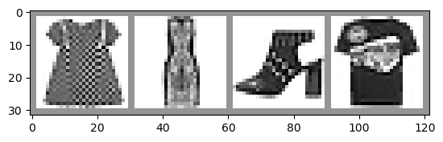

```python
# get some random training images
dataiter = iter(trainloader)
images, labels = next(dataiter)

# create grid of images
img_grid = torchvision.utils.make_grid(images)

# show images
matplotlib_imshow(img_grid, one_channel=True)

# write to tensorboard
writer.add_image('four_fashion_mnist_images', img_grid)
```

- 使用 TensorBoard 的魔法命令 %tensorboard 来启动 TensorBoard，并查看训练过程中的可视化。
- 加载 tensorboard 扩展 %load_ext tensorboard
- 启动Tensorboard服务器 %tensorboard --logdir runs --port=6006

[figure not shown]

```
from IPython.display import IFrame
IFrame(src='http://localhost:6006/', width=1000, height=600)
```

[figure not shown]

## 3. 使用 TensorBoard 检查模型

- TensorBoard 的一大优势就是能够可视化复杂的模型结构。让我们将我们构建的模型可视化。

```python
# input_to_model用于执行一次前向传播，生成计算图
writer.add_graph(model = net, input_to_model = images)
writer.close()
# 现在刷新 TensorBoard 后，你应该会看到一个如下所示的“Graphs”选项卡：
```

```
IFrame(src='http://localhost:6006/', width=1000, height=600)
```

[figure not shown]

## 向 TensorBoard 添加“投影仪”

- 我们可以通过add_embedding方法可视化高维数据的低维表示

```python
# helper function
def select_n_random(data, labels, n=100):
    '''
    Selects n random datapoints and their corresponding labels from a dataset
    '''
    assert len(data) == len(labels)
    # 用于生成一个包含从 0 到 n-1 的随机排列的整数张量
    perm = torch.randperm(len(data))
    return data[perm][:n], labels[perm][:n]

# select random images and their target indices
images, labels = select_n_random(trainset.data, trainset.targets)

# get the class labels for each image
class_labels = [classes[lab] for lab in labels]

# log embeddings
features = images.view(-1, 28 * 28)
writer.add_embedding(features,
                    metadata=class_labels,
                    label_img=images.unsqueeze(1)) # 在指定位置增加一个新的维度，使得张量的形状发生变化。
writer.close()
```

```
IFrame(src='http://localhost:6006/', width=1000, height=600)
```

[figure not shown]

## 5. 使用 TensorBoard 跟踪模型训练

```python
# helper functions

def images_to_probs(net, images):
    '''
    Generates predictions and corresponding probabilities from a trained
    network and a list of images
    '''
    output = net(images)
    # convert output probabilities to predicted class
    _, preds_tensor = torch.max(output, 1)
    preds = np.squeeze(preds_tensor.numpy())
    return preds, [F.softmax(el, dim=0)[i].item() for i, el in zip(preds, output)]
```

```python
def plot_classes_preds(net, images, labels):
    '''
    Generates matplotlib Figure using a trained network, along with images
    and labels from a batch, that shows the network's top prediction along
    with its probability, alongside the actual label, coloring this
    information based on whether the prediction was correct or not.
    Uses the "images_to_probs" function.
    '''
    preds, probs = images_to_probs(net, images)
    # plot the images in the batch, along with predicted and true labels
    fig = plt.figure(figsize=(12, 48))
    for idx in np.arange(4):
        ax = fig.add_subplot(1, 4, idx+1, xticks=[], yticks=[])
        matplotlib_imshow(images[idx], one_channel=True)
        ax.set_title("{0}, {1:.1f}%\n(label: {2})".format(
            classes[preds[idx]],
            probs[idx] * 100.0,
            classes[labels[idx]]),
                    color=("green" if preds[idx]==labels[idx].item() else "red"))
    return fig
```

```python
running_loss = 0.0
for epoch in range(1):  # loop over the dataset multiple times
    for i, data in enumerate(trainloader, 0):
        # get the inputs; data is a list of [inputs, labels]
        inputs, labels = data
        # zero the parameter gradients
        optimizer.zero_grad()

        # forward + backward + optimize
        outputs = net(inputs)
        loss = criterion(outputs, labels)
        loss.backward()
        optimizer.step()

        running_loss += loss.item()
        if i % 1000 == 999:    # every 1000 mini-batches...

            # ...log the running loss
            writer.add_scalar('training loss',
                            running_loss / 1000,
                            epoch * len(trainloader) + i)

            # ...log a Matplotlib Figure showing the model's predictions on a
            # random mini-batch
            writer.add_figure('predictions vs. actuals',
                            plot_classes_preds(net, inputs, labels),
                            global_step=epoch * len(trainloader) + i)
            running_loss = 0.0
print('Finished Training')
```

```
Finished Training
```

- 可以查看标量选项卡，查看在 15,000 次训练迭代中绘制的运行损失：

```
IFrame(src='http://localhost:6006/', width=1000, height=600)
```

[figure not shown]

- 此外，我们可以查看模型在学习过程中对任意批次做出的预测

```
IFrame(src='http://localhost:6006/', width=1000, height=600)
```

[figure not shown]

## 6. 使用 TensorBoard 评估训练好的模型

- 看到一个“PR 曲线”选项卡，其中包含每个类别的精确度-召回率曲线。

```python
# 1. gets the probability predictions in a test_size x num_classes Tensor
# 2. gets the preds in a test_size Tensor
# takes ~10 seconds to run
class_probs = []
class_label = []
with torch.no_grad():
    for data in testloader:
        images, labels = data
        output = net(images)
        class_probs_batch = [F.softmax(el, dim=0) for el in output]

        class_probs.append(class_probs_batch)
        class_label.append(labels)

test_probs = torch.cat([torch.stack(batch) for batch in class_probs])
test_label = torch.cat(class_label)
```

```python
# helper function
def add_pr_curve_tensorboard(class_index, test_probs, test_label, global_step=0):
    '''
    Takes in a "class_index" from 0 to 9 and plots the corresponding
    precision-recall curve
    '''
    tensorboard_truth = test_label == class_index
    tensorboard_probs = test_probs[:, class_index]

    writer.add_pr_curve(classes[class_index],
                        tensorboard_truth,
                        tensorboard_probs,
                        global_step=global_step)
    writer.close()

# plot all the pr curves
for i in range(len(classes)):
    add_pr_curve_tensorboard(i, test_probs, test_label)
```

```
IFrame(src='http://localhost:6006/', width=1000, height=600)
```

[figure not shown]